# Testing the ABM using the ACS

H1: Housing Segregation > Income Segregation

Malte Grönemann

2026-10-28

The formal model produces always more unevenly distrbuted features of houses in space than in population. Because investments into housing quality are based on neighborhood averages, the spatial distribution of housing quality is very smooth and quality is very similar within each neighborhood. Characteristics of the population of a neighborhood are less homogenous within neighborhoods as moves are noisier: a household might be able to afford a higher-utility unit in a different neighborhood but it is already occupied by another household, so they stay at the currently best available option and do not move to the housing unit that maximizes their utility and create perfect segregation. As rent and home value are monetary expressions of the desirability of a housing unit and therefore depend on the neighborhood, they show high spatial unevenness as well. The first hypothesis therefore states:

> Rent and housing quality are more unequally distributed in space within cities than household income.

I operationalize spatial unevenness in housing characteristics with the unevenness in home values, contract rent, and tenure type (renting vs. owning). Higher home values and rents are indicative of a higher housing quality as these housing units are likely larger, of better quality and located in better neighborhoods. To make the comparison sound, I use contract rent and therefore exclude utility costs such as water and energy as these monthly costs are also not part of the estimated home value. Higher utility costs can also be a consequence of low quality such as poor insulation or leaky pipes. As such quality issues are priced into contract rent to compensate for higher utility costs, contract rent is the cleaner choice.

In the US, the housing market is not only characterized by income segregation but also racial segregation. And the former (in combination with group differences in income) seems to be less a cause for the latter as often assumed. Instead, historical patterns of racially segregated neighborhoods reproduce itself (Krysan and Crowder 2017), effectively creating a segmented housing market. To see whether these relationships hold within race groups, I compare income and tenure segregation by three race groups: non-hispanic White, non-hispanic Black, and Hispanic/Latino. Home values and rents are not available as brackets separated by race (at least not in the publicly accessible ACS data) so that I cannot compare income segregation to rent/value segregation within race groups.

# Operationalization

Spatial unevenness is measured by the rank-order information theory index $H^R$ (Reardon & Bischoff 2011) for the continuous variables income, contract rent, and home value, and by the binary Theil $H$ for the categorical variable tenure. Both indices are bounded $[0,1]$ and scale-independent: $H^R$ is robust to bracket boundary shifts and the absolute level of the variable, so cross-city and over-time comparisons are valid without deflating to constant dollars. The two indices are conceptually consistent — $H^R$ for a binary variable reduces exactly to binary $H$ — but not identical: $H^R$ summarises segregation across the full distributional gradient by integrating binary $H$ values across all possible cutpoints, whereas $H$ for tenure captures a single renter/owner split. Comparisons between $H^R$ and $H$ are therefore meaningful as measures of overall spatial unevenness but should not be interpreted as the same underlying quantity.

A further difference in universe should be noted: $H_{inc}$ is computed over all households, whereas $H_{rent}$ covers only cash-rent-paying renters (B25056) and $H_{val}$ only owner-occupiers (B25075). In principle this could inflate the housing indices if renters or owners are already more spatially concentrated as subpopulations. In practice, however, $H^R$ is distribution-invariant — it captures how unevenly the *within-universe* distribution of rents or values is spread across tracts — so the comparison remains meaningful as a test of whether each housing dimension is more spatially unequal than income within its respective population.

# Description of Segregation

## Income and Housing Segregation

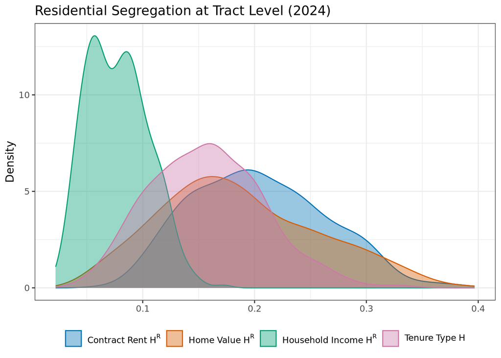

When looking at how features of their population and their housing stock are spatially distributed within cities, we can see that income segregation tend to be much lower on average and varies less between cities than features of their housing stock. Contract rent, estimated home values and type of tenure are more unequally located in space in cities and cities vary quite significantly. This already hints at the hypothesis that housing tends to be more unequally distributed in space than population.

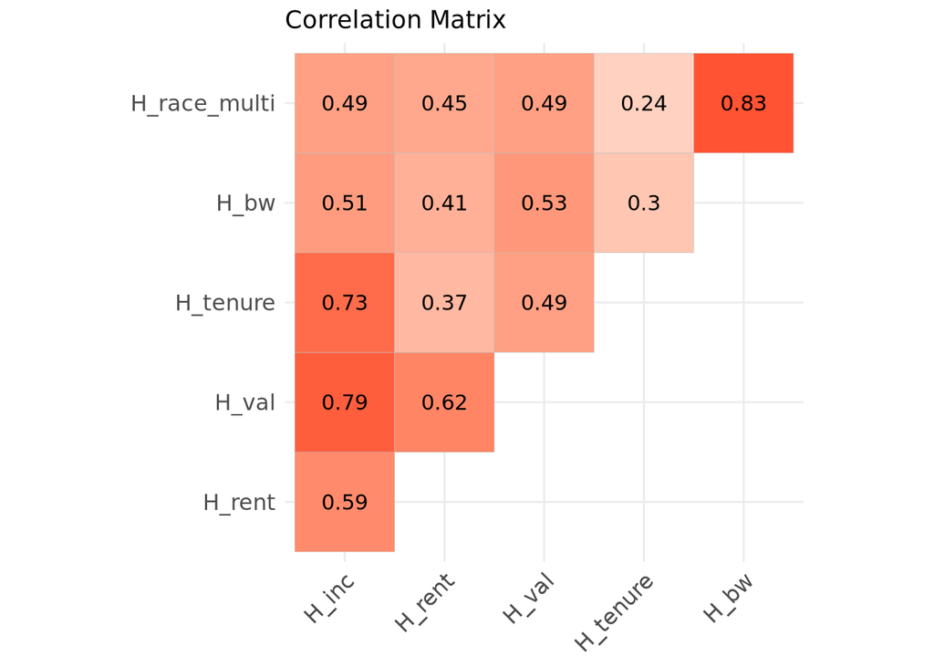

The two racial measures correlate 0.83, which is partly definitional, since multigroup segregation contains the Black–White contrast as a component. More informative is that both relate almost identically to everything else. Extending the measure to Hispanics and other groups changes nothing about how racial segregation maps onto the housing dimensions. Racial segregation is moderately associated with income and value segregation and a bit less with rent and tenure segregation.

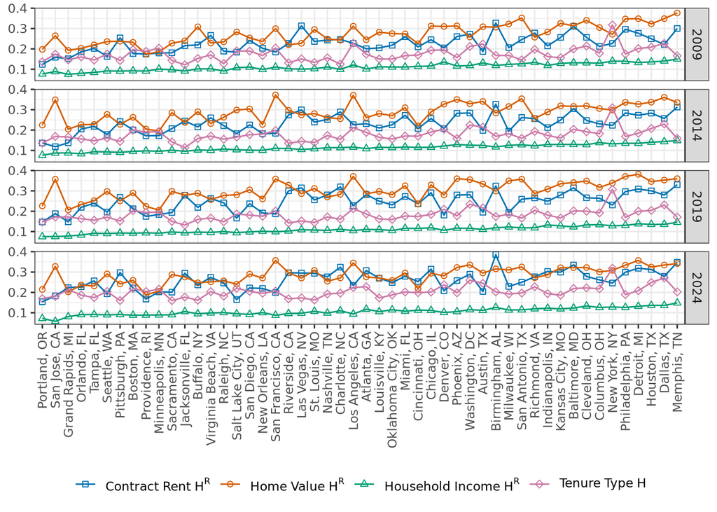

## Regional Differences in Segregation

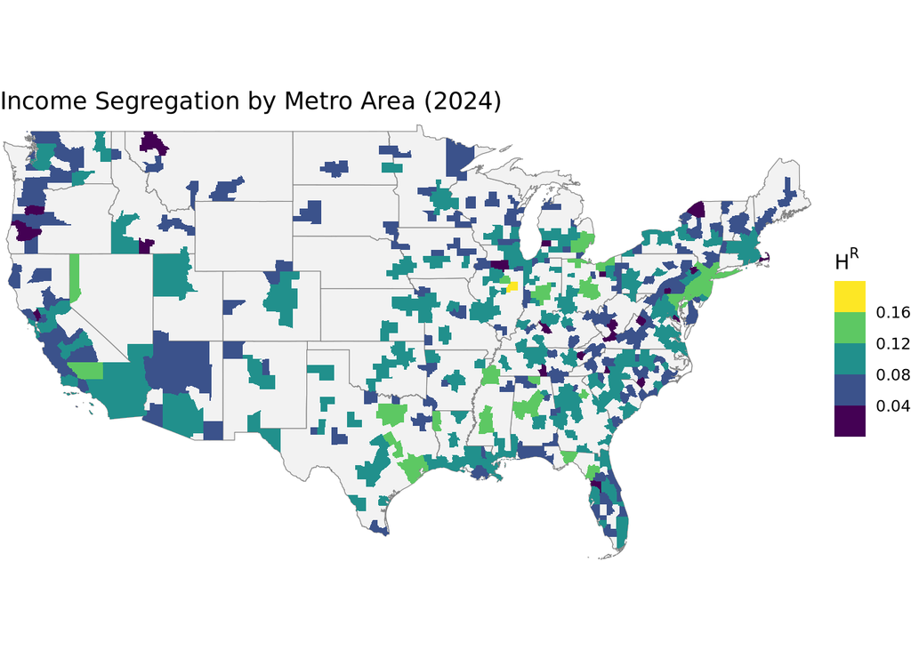

There does not appear to be a strong regional difference in income segregation.

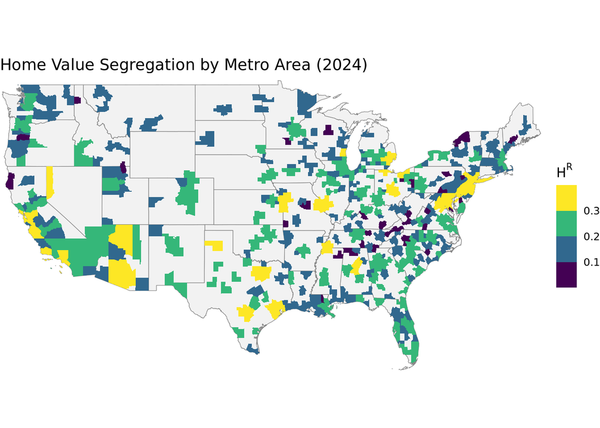

Value segregation tends to be low in the Pacific North-West, New England, parts of the Midwest and the South-East. Value segregation is highest in California, Texas and some cities on the East Coast.

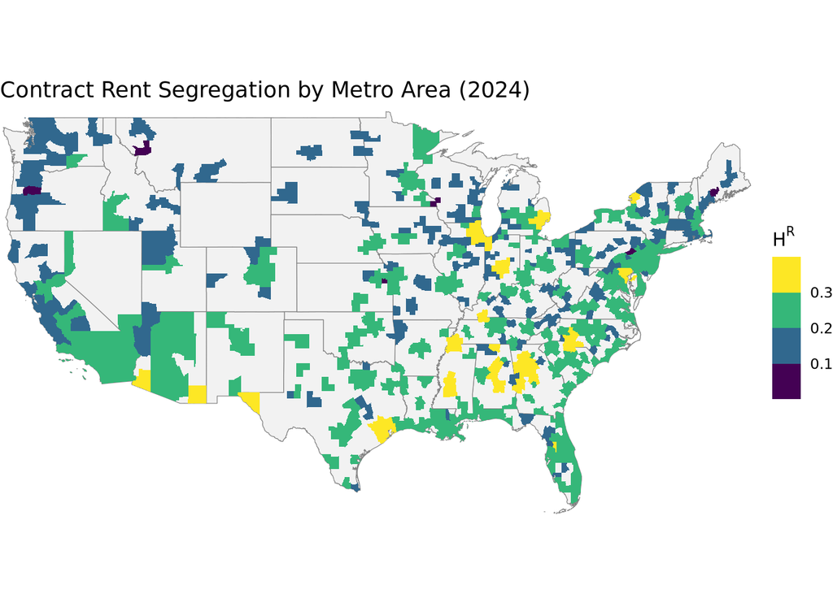

Rent segregation largely follows the geographic pattern of value segregation, although Florida and some Southern states appear to be more spatially unequal in rent relative to home values.

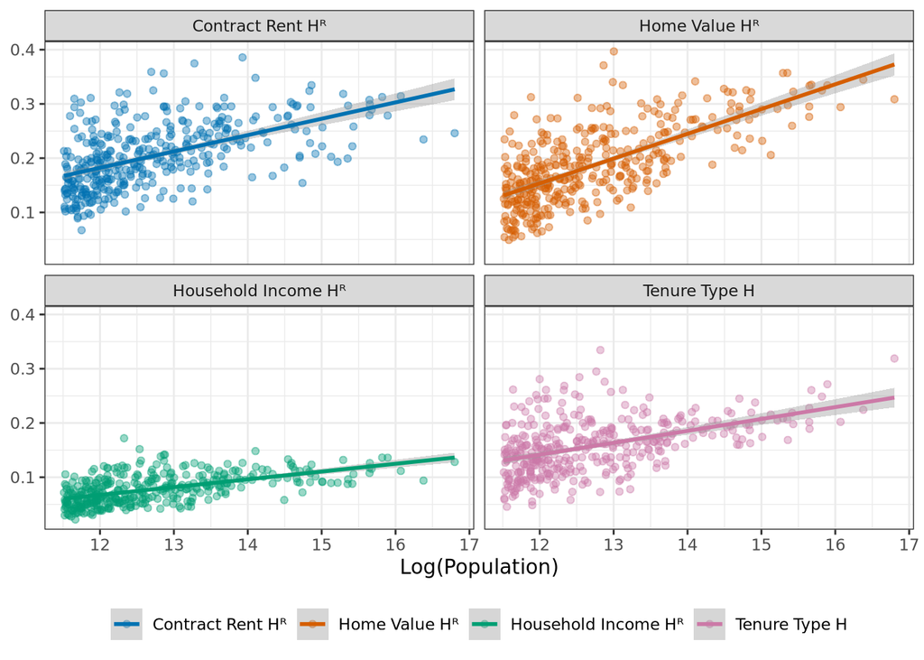

The maps and the plot showing the largest fifty metropolitan areas already hinted at a possible relationship of segregation with population size. More populous metros tend to be more segregated in all dimensions. But as there are much more smaller metros, the variation in segregation is large. Variation in segregation also declines with population size.

## Changes in Residential Segregation

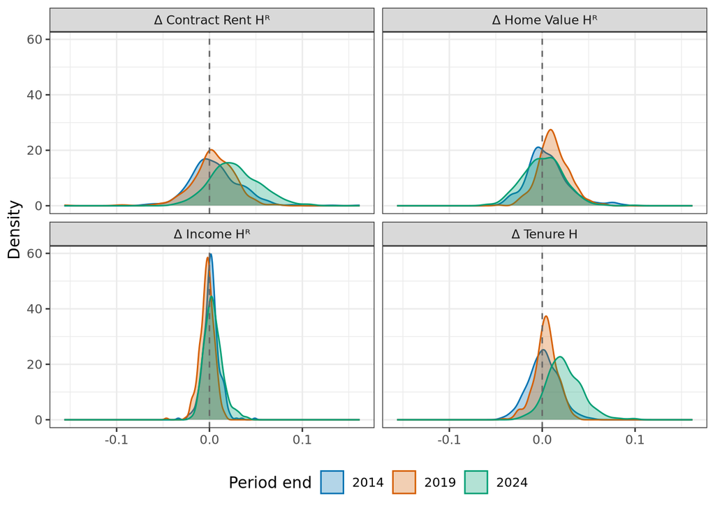

Residential segregation is very stable over time and it usually takes decades for substantive changes in levels of segregation within a metro area. The plot above shows indeed that segregation levels only change slightly between the 5-year ACS windows. And part of it will be noise from sampling. Interestingly, though, changes in income segregation have been smallest while changes in spatial unevenness of contract rent is highest. Unevenness in contract rent also appears to have increases from 2019 to 2024. Home value and tenure have changed more than income segregation but less than rent. Home value segregation increased overall from 2014 to 2019. Surprisingly, as built houses should be very slow to change, tenure segregation increased the most, especially from 2019 to 2024.

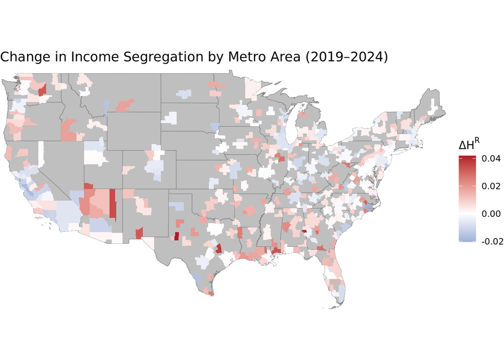

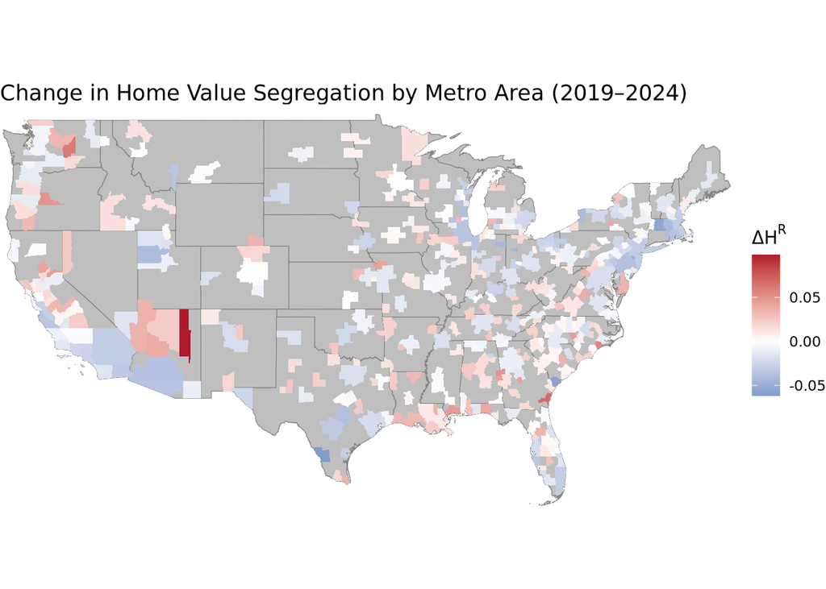

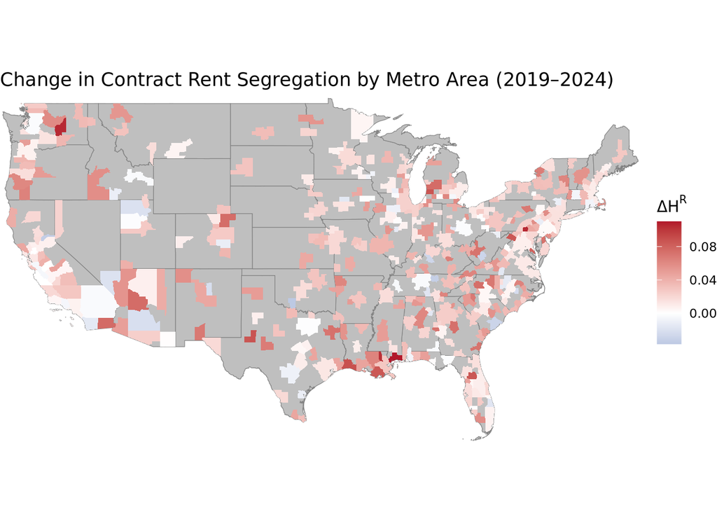

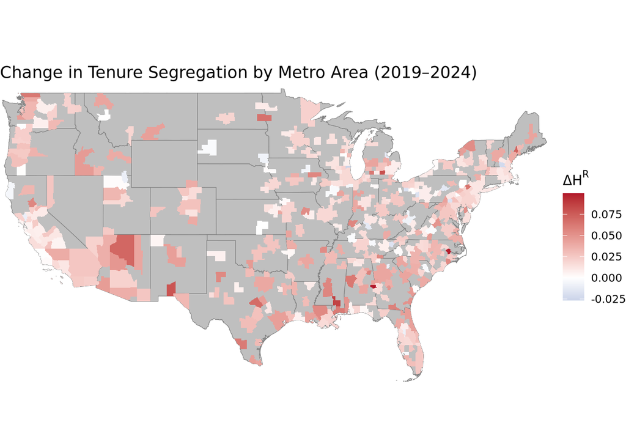

## Within-Race Income and Tenure Segregation Segregation

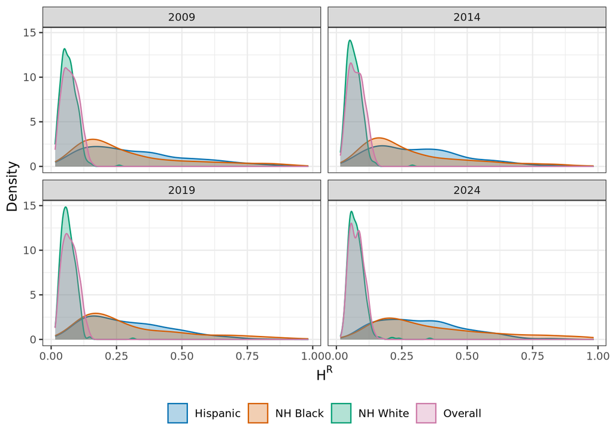

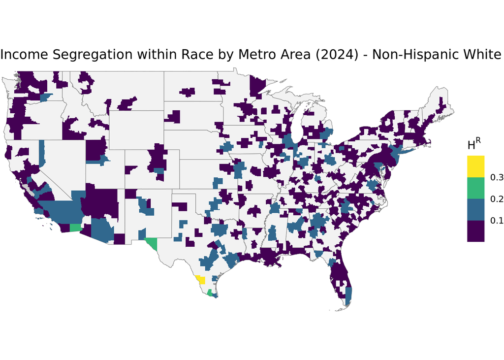

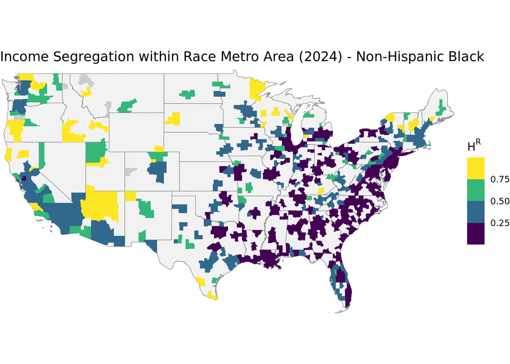

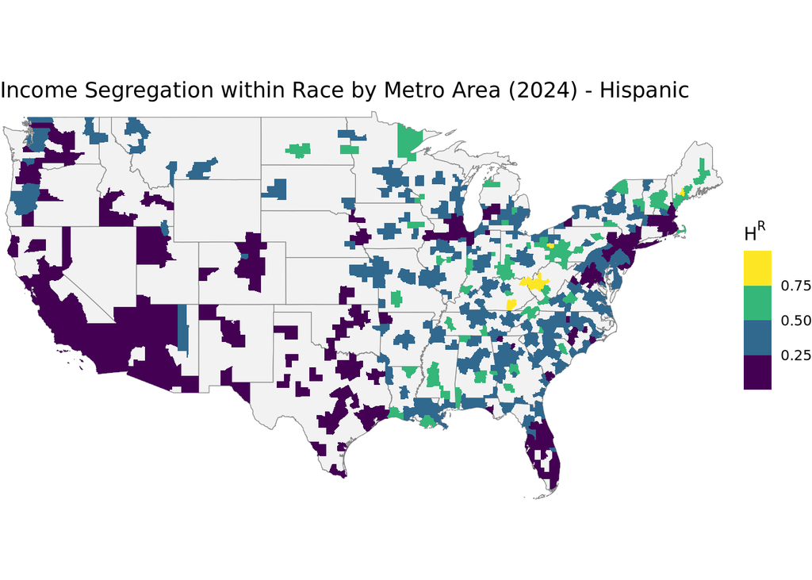

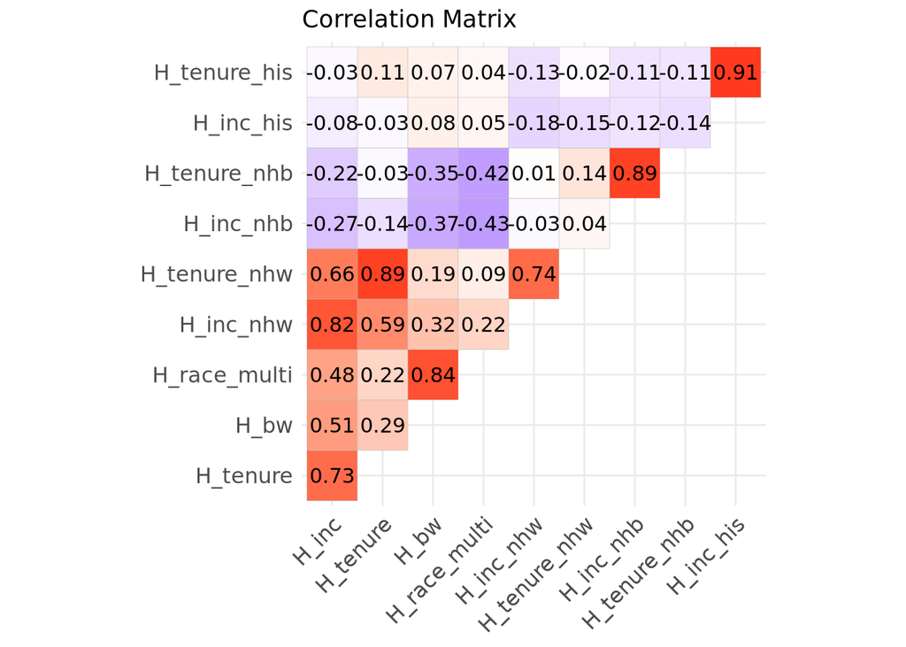

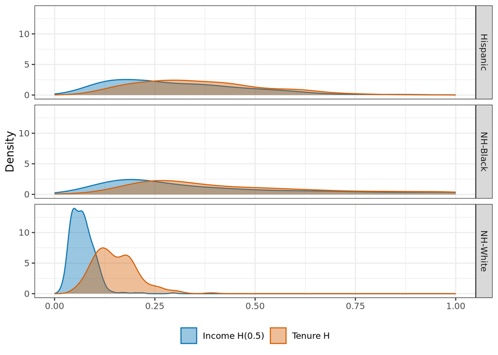

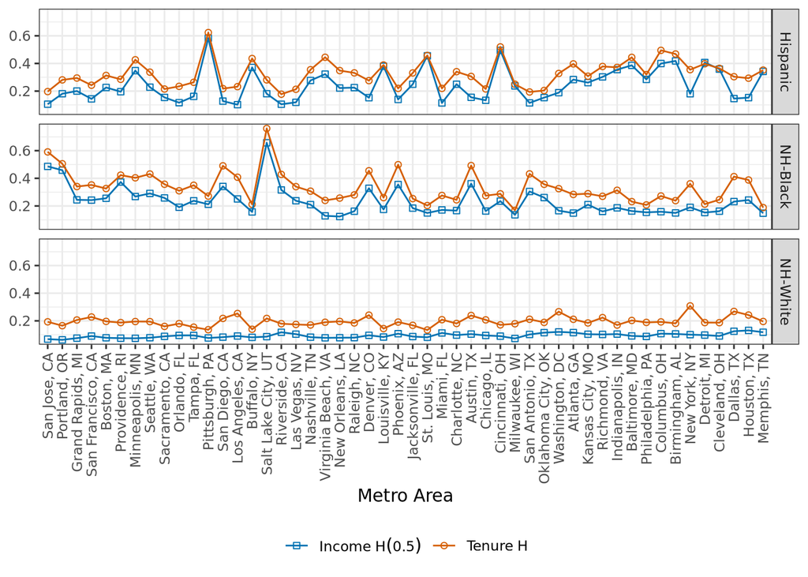

# Test of the Hypothesis

The following plot shows the proportion of metro area x years where rent, value, or tenure segregation exceed segregation by household income, first in general (upper panel) and then separated by race (lower panel) to test the hypothesis.

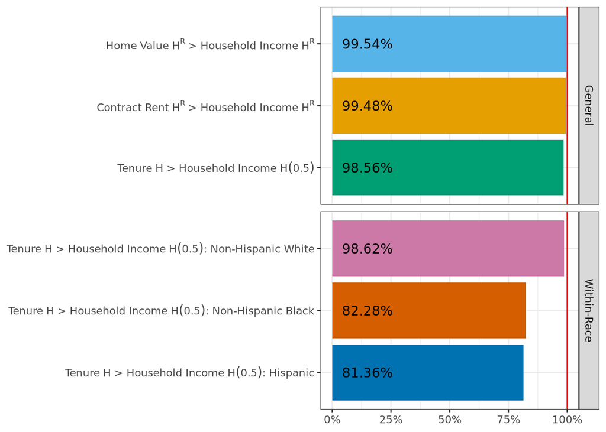

For the cases where not all metropolitan areas have higher housing segregation than income segregation, I test whether we can reject the null hypothesis that the true proportion in the population is 1 based on the data. Although this is somewhat of a fallacy, as one metro where this is the case disproves the hypothesis, it is still insightful to see how strong this fact is. I test the hypothesis $H_0: \pi = 1$ using an intercept-only linear probability model comparing tenure $H$ and income $H(0.5)$. This way, we do not want to reject the null hypothesis to get support for the model. Because proportions are bounded between 0 and 1, the alternate hypothesis needs to be $H_1: \pi < 1$ but the LPM performs a two-sided test. We therefore need to double p-values in the interpretation.

|  | (1) | (2) | (3) | (4) |
| --- | --- | --- | --- | --- |
| Sample | All households | NH White | NH Black | Hispanic |
| Proportion − 1 | −0.014+ | −0.014+ | −0.177*** | −0.186** |
|  | (0.006) | (0.005) | (0.012) | (0.015) |
|  | p 0.091 | p 0.064 | p <0.001 | p 0.001 |
| Num.Obs. | 1524 | 1524 | 1524 | 1524 |

The intercept-only LPM confirms the result that housing segregation exceeds income segregation overwhelmingly for Whites and in the overall assessment. The doubled p-value in both cases exceed ten percent and the proportion is therefore not significantly different from 1. But for Blacks and Hispanics, the difference is sizeable and significant.

I interpret these findings as tentative support for the model. In general, features of the housing stock appear to be more unevenly placed in space as characteristics of households. I deem this hypothesis not a strong hypothesis though as there are several limitations to it, both from the working of the simulation model and the available empirical data. First, the ABM simulated features of the housing unit with only one variable, housing quality, and all households only differ in income and status, not in size and composition. In reality, a large part of rent and value depend on the size of the housing unit and the size and layout of the home needs to fit the household composition. A rich couple might occupy a very high quality loft that costs the same as a decent single family home. The price of a home and their income can mean very different things to different households with different needs. But there are no (spatial) information on price per square meter or equivalence weighted income in the ACS tables, whose comparison might approximate the hypothesis better. However, unit size is endogenous to the developers’ decision and to be able to afford a home, total household income income matters, not equivalence weighted income. The shown comparison is therefore internally consistent and every comparison would suffer from an endogeneity problem. Second, the ABM models segregation as a self-organizing process while in reality, building codes and zoning laws could enforce the spatial uneveness of tenure and prices. But as such laws may be a strategy of existing homeowners to secure their assets (Rothwell and Massey 2010), regulations might be passed or changed after an endogenous process of segregation, again creating an endogeneity/simultaneity problem. As a bottom line, the empirical observation is mostly in line with the empirical expectation derived from the model and does not outright refuse it. The question why this pattern differs for racial minorities is an interesting question for further research, though.